# BikeShareAnalysis

Jorge Chavez

6/29/2021

## Introduction

This analysis is for case study “‘Sophisticated, Clear, and Polished’: Divvy and Data Visualization” written by Kevin Hartman (found here:https://artscience.blog/home/divvy-dataviz-case-study)

We will be using the Divvy dataset for the case study. The timeframe for our data analysis runs from April, 2020 through May, 2021. The purpose of this script is to consolidate Divvy data into a single dataframe, conduct simple analysis, and visualize trends to help answer our key question: “In what ways do members and casual riders use Divvy bikes differently?”

First, we will install the packages that will help us get to our solution.

```r
library(tidyverse) #used for wrangling data
library(lubridate) #used for wrangling date attributes
```

```r
library(ggplot2) #used for visualizing data
library(readxl) #used for reading Excel files
```

## Data Preparation

Excel was previously used to clean the data sets from duplicates and missing information using conditional formatting. Files were also reduced to a sample size.

Columns such as the day of the week, ditance traveled, and length of trip were added to each dataset for a more efficient data analysis.

```r
apr_2020 <- read_excel("C:\\Users\\chave\\Documents\\BikeShareExcel\\202004BikeShare.xlsx")

may_2020 <- read_excel("C:\\Users\\chave\\Documents\\BikeShareExcel\\202005BikeShare.xlsx")

jun_2020 <- read_excel("C:\\Users\\chave\\Documents\\BikeShareExcel\\202006BikeShare.xlsx")

jul_2020 <- read_excel("C:\\Users\\chave\\Documents\\BikeShareExcel\\202007BikeShare.xlsx")

aug_2020 <- read_excel("C:\\Users\\chave\\Documents\\BikeShareExcel\\202008BikeShare.xlsx")

sep_2020 <- read_excel("C:\\Users\\chave\\Documents\\BikeShareExcel\\202009BikeShare.xlsx")

oct_2020 <- read_excel("C:\\Users\\chave\\Documents\\BikeShareExcel\\202010BikeShare.xlsx")

nov_2020 <- read_excel("C:\\Users\\chave\\Documents\\BikeShareExcel\\202011BikeShare.xlsx")

dec_2020 <- read_excel("C:\\Users\\chave\\Documents\\BikeShareExcel\\202012BikeShare.xlsx")
```

[output not shown]

[output cut: 58 more lines]

[output not shown]

```r
jan_2021 <- read_excel("C:\\Users\\chave\\Documents\\BikeShareExcel\\202101BikeShare.xlsx")

feb_2021 <- read_excel("C:\\Users\\chave\\Documents\\BikeShareExcel\\202102BikeShare.xlsx")

mar_2021 <- read_excel("C:\\Users\\chave\\Documents\\BikeShareExcel\\202103BikeShare.xlsx")

apr_2021 <- read_excel("C:\\Users\\chave\\Documents\\BikeShareExcel\\202104BikeShare.xlsx")

may_2021 <- read_excel("C:\\Users\\chave\\Documents\\BikeShareExcel\\202105BikeShare.xlsx")
```

## Data Wrangling & File Combination

Observe column names of files to ensure they match among across all data sets.

```r
colnames(apr_2020)
```

```
##  [1] "ride_id"            "rideable_type"      "started_at"
##  [4] "ended_at"           "start_station_name" "start_station_id"
##  [7] "end_station_name"   "end_station_id"     "start_lat"
## [10] "start_lng"          "end_lat"            "end_lng"
## [13] "member_casual"      "ride_length"        "day_of_week"
## [16] "distance"
```

```r
colnames(may_2020)
```

```
##  [1] "ride_id"            "rideable_type"      "started_at"
##  [4] "ended_at"           "start_station_name" "start_station_id"
##  [7] "end_station_name"   "end_station_id"     "start_lat"
## [10] "start_lng"          "end_lat"            "end_lng"
## [13] "member_casual"      "ride_length"        "day_of_week"
## [16] "distance"
```

```r
colnames(jun_2020)
```

```
##  [1] "ride_id"            "rideable_type"      "started_at"
##  [4] "ended_at"           "start_station_name" "start_station_id"
##  [7] "end_station_name"   "end_station_id"     "start_lat"
## [10] "start_lng"          "end_lat"            "end_lng"
## [13] "member_casual"      "ride_length"        "day_of_week"
## [16] "distance"
```

```r
colnames(jul_2020)
```

```
##  [1] "ride_id"            "rideable_type"      "started_at"
##  [4] "ended_at"           "start_station_name" "start_station_id"
##  [7] "end_station_name"   "end_station_id"     "start_lat"
## [10] "start_lng"          "end_lat"            "end_lng"
## [13] "member_casual"      "ride_length"        "day_of_week"
## [16] "distance"
```

```r
colnames(aug_2020)
```

```
##  [1] "ride_id"            "rideable_type"      "started_at"
##  [4] "ended_at"           "start_station_name" "start_station_id"
##  [7] "end_station_name"   "end_station_id"     "start_lat"
## [10] "start_lng"          "end_lat"            "end_lng"
## [13] "member_casual"      "ride_length"        "day_of_week"
## [16] "distance"
```

```r
colnames(sep_2020)
```

```
##  [1] "ride_id"            "rideable_type"      "started_at"
##  [4] "ended_at"           "start_station_name" "start_station_id"
##  [7] "end_station_name"   "end_station_id"     "start_lat"
## [10] "start_lng"          "end_lat"            "end_lng"
## [13] "member_casual"      "ride_length"        "day_of_week"
## [16] "distance"
```

```r
colnames(oct_2020)
```

```
##  [1] "ride_id"            "rideable_type"      "started_at"
##  [4] "ended_at"           "start_station_name" "start_station_id"
##  [7] "end_station_name"   "end_station_id"     "start_lat"
## [10] "start_lng"          "end_lat"            "end_lng"
## [13] "member_casual"      "ride_length"        "day_of_week"
## [16] "distance"
```

```r
colnames(nov_2020)
```

```
##  [1] "ride_id"            "rideable_type"      "started_at"
##  [4] "ended_at"           "start_station_name" "start_station_id"
##  [7] "end_station_name"   "end_station_id"     "start_lat"
## [10] "start_lng"          "end_lat"            "end_lng"
## [13] "member_casual"      "ride_length"        "day_of_week"
## [16] "distance"
```

```r
colnames(dec_2020)
```

```
##  [1] "ride_id"            "rideable_type"      "started_at"
##  [4] "ended_at"           "start_station_name" "start_station_id"
##  [7] "end_station_name"   "end_station_id"     "start_lat"
## [10] "start_lng"          "end_lat"            "end_lng"
## [13] "member_casual"      "ride_length"        "day_of_week"
## [16] "distance"
```

```r
colnames(jan_2021)
```

```
##  [1] "ride_id"            "rideable_type"      "started_at"
##  [4] "ended_at"           "start_station_name" "start_station_id"
##  [7] "end_station_name"   "end_station_id"     "start_lat"
## [10] "start_lng"          "end_lat"            "end_lng"
## [13] "member_casual"      "ride_length"        "day_of_week"
## [16] "distance"
```

```r
colnames(feb_2021)
```

```
##  [1] "ride_id"            "rideable_type"      "started_at"
##  [4] "ended_at"           "start_station_name" "start_station_id"
##  [7] "end_station_name"   "end_station_id"     "start_lat"
## [10] "start_lng"          "end_lat"            "end_lng"
## [13] "member_casual"      "ride_length"        "day_of_week"
## [16] "distance"
```

```r
colnames(mar_2021)
```

```
##  [1] "ride_id"            "rideable_type"      "started_at"
##  [4] "ended_at"           "start_station_name" "start_station_id"
##  [7] "end_station_name"   "end_station_id"     "start_lat"
## [10] "start_lng"          "end_lat"            "end_lng"
## [13] "member_casual"      "ride_length"        "day_of_week"
## [16] "distance"
```

```r
colnames(apr_2021)
```

```
##  [1] "ride_id"            "rideable_type"      "started_at"
##  [4] "ended_at"           "start_station_name" "start_station_id"
##  [7] "end_station_name"   "end_station_id"     "start_lat"
## [10] "start_lng"          "end_lat"            "end_lng"
## [13] "member_casual"      "ride_length"        "day_of_week"
## [16] "distance"
```

```r
colnames(may_2021)
```

```
##  [1] "ride_id"            "rideable_type"      "started_at"
##  [4] "ended_at"           "start_station_name" "start_station_id"
##  [7] "end_station_name"   "end_station_id"     "start_lat"
## [10] "start_lng"          "end_lat"            "end_lng"
## [13] "member_casual"      "ride_length"        "day_of_week"
## [16] "distance"
```

Inspecting our files dataframes to find potential inconsistencies.

```r
str(apr_2020)
```

```
## tibble [10,735 x 16] (S3: tbl_df/tbl/data.frame)
##  $ ride_id           : chr [1:10735] "D299A8CF86191877" "00FC16EC0DB7B441" "313545028867D93B" "C487F420130E0FD2" ...
##  $ rideable_type     : chr [1:10735] "docked_bike" "docked_bike" "docked_bike" "docked_bike" ...
##  $ started_at        : POSIXct[1:10735], format: "2020-04-30 17:36:50" "2020-04-16 17:21:04" ...
##  $ ended_at          : POSIXct[1:10735], format: "2020-04-30 17:39:03" "2020-04-16 18:47:34" ...
##  $ start_station_name: chr [1:10735] "Clinton St & Madison St" "Lake Shore Dr & North Blvd" "Lake Shore Dr & Monroe St" "Lake Shore Dr & Monroe St" ...
##  $ start_station_id  : num [1:10735] 77 268 76 76 304 186 24 598 179 322 ...
##  $ end_station_name  : chr [1:10735] "Clinton St & Lake St" "Lake Shore Dr & North Blvd" "Millennium Park" "Millennium Park" ...
##  $ end_station_id    : num [1:10735] 66 268 90 90 304 198 52 519 335 351 ...
##  $ start_lat         : num [1:10735] 41.9 41.9 41.9 41.9 41.9 ...
##  $ start_lng         : num [1:10735] -87.6 -87.6 -87.6 -87.6 -87.6 ...
##  $ end_lat           : num [1:10735] 41.9 41.9 41.9 41.9 41.9 ...
##  $ end_lng           : num [1:10735] -87.6 -87.6 -87.6 -87.6 -87.6 ...
##  $ member_casual     : chr [1:10735] "casual" "casual" "member" "member" ...
##  $ ride_length       : POSIXct[1:10735], format: "1899-12-31 00:02:13" "1899-12-31 01:26:30" ...
##  $ day_of_week       : POSIXct[1:10735], format: "2020-04-30 17:36:50" "2020-04-16 17:21:04" ...
##  $ distance          : num [1:10735] 2.07e-01 0.00 3.31e-01 3.31e-01 5.13e-05 ...
```

```r
str(may_2020)
```

```
## tibble [24,752 x 16] (S3: tbl_df/tbl/data.frame)
##  $ ride_id           : chr [1:24752] "7A50CCAF1EDDB28F" "2500D7957D4D0A34" "197085F3EC7F5508" "33EA7C57267B1D42" ...
##  $ rideable_type     : chr [1:24752] "docked_bike" "docked_bike" "docked_bike" "docked_bike" ...
##  $ started_at        : POSIXct[1:24752], format: "2020-05-25 10:47:11" "2020-05-20 12:51:41" ...
##  $ ended_at          : POSIXct[1:24752], format: "2020-05-25 11:05:40" "2020-05-20 13:46:47" ...
##  $ start_station_name: chr [1:24752] "Clark St & Wrightwood Ave" "Hermitage Ave & Polk St" "Ashland Ave & Belle Plaine Ave" "Southport Ave & Irving Park Rd" ...
##  $ start_station_id  : num [1:24752] 340 261 246 318 461 587 181 140 300 223 ...
##  $ end_station_name  : chr [1:24752] "Clark St & Leland Ave" "Hermitage Ave & Polk St" "Southport Ave & Roscoe St" "Pine Grove Ave & Waveland Ave" ...
##  $ end_station_id    : num [1:24752] 326 261 229 232 525 201 110 181 181 210 ...
##  $ start_lat         : num [1:24752] 41.9 41.9 42 42 42 ...
##  $ start_lng         : num [1:24752] -87.6 -87.7 -87.7 -87.7 -87.7 ...
##  $ end_lat           : num [1:24752] 42 41.9 41.9 41.9 42 ...
##  $ end_lng           : num [1:24752] -87.7 -87.7 -87.7 -87.6 -87.7 ...
##  $ member_casual     : chr [1:24752] "casual" "member" "casual" "member" ...
##  $ ride_length       : POSIXct[1:24752], format: "1899-12-31 00:18:29" "1899-12-31 00:55:06" ...
##  $ day_of_week       : POSIXct[1:24752], format: "2020-05-25 10:47:11" "2020-05-20 12:51:41" ...
##  $ distance          : num [1:24752] 2.508 0 0.776 0.861 1.744 ...
```

```r
str(jun_2020)
```

```
## tibble [42,879 x 16] (S3: tbl_df/tbl/data.frame)
##  $ ride_id           : chr [1:42879] "BE9295A1613C61A3" "3A7F9C02EC7173DF" "861FD3D4AB519DC5" "F1FB8C6B3D2F2B0C" ...
##  $ rideable_type     : chr [1:42879] "docked_bike" "docked_bike" "docked_bike" "docked_bike" ...
##  $ started_at        : POSIXct[1:42879], format: "2020-06-19 13:58:15" "2020-06-27 22:57:37" ...
##  $ ended_at          : POSIXct[1:42879], format: "2020-06-19 14:15:32" "2020-06-27 23:08:37" ...
##  $ start_station_name: chr [1:42879] "State St & 33rd St" "Mies van der Rohe Way & Chestnut St" "Lincoln Ave & Belle Plaine Ave" "Sheffield Ave & Willow St" ...
##  $ start_station_id  : num [1:42879] 148 145 298 93 117 157 136 56 349 93 ...
##  $ end_station_name  : chr [1:42879] "Calumet Ave & 18th St" "Wells St & Evergreen Ave" "Lakeview Ave & Fullerton Pkwy" "Orleans St & Hubbard St" ...
##  $ end_station_id    : num [1:42879] 338 291 313 636 117 254 22 107 475 291 ...
##  $ start_lat         : num [1:42879] 41.8 41.9 42 41.9 41.9 ...
##  $ start_lng         : num [1:42879] -87.6 -87.6 -87.7 -87.7 -87.7 ...
##  $ end_lat           : num [1:42879] 41.9 41.9 41.9 41.9 41.9 ...
##  $ end_lng           : num [1:42879] -87.6 -87.6 -87.6 -87.6 -87.7 ...
##  $ member_casual     : chr [1:42879] "member" "member" "casual" "member" ...
##  $ ride_length       : POSIXct[1:42879], format: "1899-12-31 00:17:17" "1899-12-31 00:11:00" ...
##  $ day_of_week       : POSIXct[1:42879], format: "2020-06-19 13:58:15" "2020-06-27 22:57:37" ...
##  $ distance          : num [1:42879] 1.405 0.757 2.583 1.597 0 ...
```

```r
str(jul_2020)
```

```
## tibble [68,980 x 16] (S3: tbl_df/tbl/data.frame)
##  $ ride_id           : chr [1:68980] "54AE594E20B35881" "7FA38D309B160B59" "8CE8D05B0044D078" "DE01B99C20522392" ...
##  $ rideable_type     : chr [1:68980] "docked_bike" "docked_bike" "docked_bike" "docked_bike" ...
##  $ started_at        : POSIXct[1:68980], format: "2020-07-17 19:06:42" "2020-07-08 23:06:14" ...
##  $ ended_at          : POSIXct[1:68980], format: "2020-07-17 19:27:38" "2020-07-08 23:12:24" ...
##  $ start_station_name: chr [1:68980] "LaSalle St & Illinois St" "Wells St & Elm St" "Lake Shore Dr & Belmont Ave" "Wells St & Elm St" ...
##  $ start_station_id  : num [1:68980] 181 182 334 182 56 233 198 284 131 398 ...
##  $ end_station_name  : chr [1:68980] "Clark St & Armitage Ave" "State St & Pearson St" "Lake Shore Dr & Wellington Ave" "Ritchie Ct & Banks St" ...
##  $ end_station_id    : num [1:68980] 94 106 157 180 186 86 196 6 242 419 ...
##  $ start_lat         : num [1:68980] 41.9 41.9 41.9 41.9 41.9 ...
##  $ start_lng         : num [1:68980] -87.6 -87.6 -87.6 -87.6 -87.6 ...
##  $ end_lat           : num [1:68980] 41.9 41.9 41.9 41.9 41.9 ...
##  $ end_lng           : num [1:68980] -87.6 -87.6 -87.6 -87.6 -87.7 ...
##  $ member_casual     : chr [1:68980] "casual" "casual" "casual" "casual" ...
##  $ ride_length       : POSIXct[1:68980], format: "1899-12-31 00:20:56" "1899-12-31 00:06:10" ...
##  $ day_of_week       : POSIXct[1:68980], format: "2020-07-17 19:06:42" "2020-07-08 23:06:14" ...
##  $ distance          : num [1:68980] 1.668 0.428 0.267 0.424 0.666 ...
```

```r
str(aug_2020)
```

```
## tibble [76,020 x 16] (S3: tbl_df/tbl/data.frame)
##  $ ride_id           : chr [1:76020] "C79FBBD412E578A7" "56349A5A42F0AE51" "9C02C90BA1FF8447" "B57305A18D7FA868" ...
##  $ rideable_type     : chr [1:76020] "electric_bike" "electric_bike" "electric_bike" "electric_bike" ...
##  $ started_at        : POSIXct[1:76020], format: "2020-08-27 12:05:41" "2020-08-27 17:26:23" ...
##  $ ended_at          : POSIXct[1:76020], format: "2020-08-27 12:53:45" "2020-08-27 18:07:50" ...
##  $ start_station_name: chr [1:76020] "Daley Center Plaza" "Leavitt St & Division St" "Noble St & Milwaukee Ave" "Southport Ave & Belmont Ave" ...
##  $ start_station_id  : num [1:76020] 81 658 29 154 177 35 71 217 72 211 ...
##  $ end_station_name  : chr [1:76020] "State St & Kinzie St" "Leavitt St & Division St" "Green St & Randolph St" "Clark St & Wrightwood Ave" ...
##  $ end_station_id    : num [1:76020] 47 658 112 340 214 211 117 51 351 99 ...
##  $ start_lat         : num [1:76020] 41.9 41.9 41.9 41.9 41.9 ...
##  $ start_lng         : num [1:76020] -87.6 -87.7 -87.7 -87.7 -87.6 ...
##  $ end_lat           : num [1:76020] 41.9 41.9 41.9 41.9 41.9 ...
##  $ end_lng           : num [1:76020] -87.6 -87.7 -87.6 -87.6 -87.7 ...
##  $ member_casual     : chr [1:76020] "casual" "casual" "casual" "casual" ...
##  $ ride_length       : POSIXct[1:76020], format: "1899-12-31 00:48:04" "1899-12-31 00:41:27" ...
##  $ day_of_week       : POSIXct[1:76020], format: "2020-08-27 12:05:41" "2020-08-27 17:26:23" ...
##  $ distance          : num [1:76020] 0.34309 0.00653 1.19351 1.09157 2.9357 ...
```

```r
str(sep_2020)
```

```
## tibble [62,647 x 16] (S3: tbl_df/tbl/data.frame)
##  $ ride_id           : chr [1:62647] "B9C4712F78C1AE68" "8A7CE19C3C3E0CA5" "9B33691497333B78" "11F9542305E48E31" ...
##  $ rideable_type     : chr [1:62647] "electric_bike" "electric_bike" "electric_bike" "electric_bike" ...
##  $ started_at        : POSIXct[1:62647], format: "2020-09-17 15:16:13" "2020-09-16 22:58:41" ...
##  $ ended_at          : POSIXct[1:62647], format: "2020-09-17 15:52:55" "2020-09-17 00:09:31" ...
##  $ start_station_name: chr [1:62647] "Fairbanks Ct & Grand Ave" "Michigan Ave & 18th St" "Wells St & Huron St" "Franklin St & Lake St" ...
##  $ start_station_id  : num [1:62647] 24 273 53 164 111 301 250 453 126 423 ...
##  $ end_station_name  : chr [1:62647] "Fairbanks Ct & Grand Ave" "Michigan Ave & 18th St" "Federal St & Polk St" "Franklin St & Lake St" ...
##  $ end_station_id    : num [1:62647] 24 273 41 164 59 349 226 243 131 247 ...
##  $ start_lat         : num [1:62647] 41.9 41.9 41.9 41.9 41.9 ...
##  $ start_lng         : num [1:62647] -87.6 -87.6 -87.6 -87.6 -87.6 ...
##  $ end_lat           : num [1:62647] 41.9 41.9 41.9 41.9 41.9 ...
##  $ end_lng           : num [1:62647] -87.6 -87.6 -87.6 -87.6 -87.6 ...
##  $ member_casual     : chr [1:62647] "casual" "casual" "casual" "casual" ...
##  $ ride_length       : POSIXct[1:62647], format: "1899-12-31 00:36:42" "1899-12-31 01:10:50" ...
##  $ day_of_week       : POSIXct[1:62647], format: "2020-09-17 15:16:13" "2020-09-16 22:58:41" ...
##  $ distance          : num [1:62647] 0.04343 0.00343 1.37416 0.04063 1.73002 ...
```

```r
str(oct_2020)
```

```
## tibble [42,418 x 16] (S3: tbl_df/tbl/data.frame)
##  $ ride_id           : chr [1:42418] "5783F4C7A8F71402" "55D7218E9B555FE3" "2788B095A61CDDFA" "B6C5C3897416494F" ...
##  $ rideable_type     : chr [1:42418] "electric_bike" "electric_bike" "electric_bike" "electric_bike" ...
##  $ started_at        : POSIXct[1:42418], format: "2020-10-25 22:11:50" "2020-10-26 10:29:35" ...
##  $ ended_at          : POSIXct[1:42418], format: "2020-10-25 22:18:43" "2020-10-26 10:29:38" ...
##  $ start_station_name: chr [1:42418] "California Ave & Division St" "WATSON TESTING - DIVVY" "WATSON TESTING - DIVVY" "Mies van der Rohe Way & Chestnut St" ...
##  $ start_station_id  : num [1:42418] 216 676 676 145 172 326 35 676 220 220 ...
##  $ end_station_name  : chr [1:42418] "Damen Ave & Pierce Ave" "WATSON TESTING - DIVVY" "WATSON TESTING - DIVVY" "Fairbanks Ct & Grand Ave" ...
##  $ end_station_id    : num [1:42418] 69 676 676 24 126 164 24 676 114 332 ...
##  $ start_lat         : num [1:42418] 41.9 41.9 41.9 41.9 41.9 ...
##  $ start_lng         : num [1:42418] -87.7 -87.7 -87.7 -87.6 -87.6 ...
##  $ end_lat           : num [1:42418] 41.9 41.9 41.9 41.9 41.9 ...
##  $ end_lng           : num [1:42418] -87.7 -87.7 -87.7 -87.6 -87.6 ...
##  $ member_casual     : chr [1:42418] "casual" "casual" "casual" "casual" ...
##  $ ride_length       : POSIXct[1:42418], format: "1899-12-31 00:06:53" "1899-12-31 00:00:03" ...
##  $ day_of_week       : POSIXct[1:42418], format: "2020-10-25 22:11:50" "2020-10-26 10:29:35" ...
##  $ distance          : num [1:42418] 0.9686 0.00182 0.00144 0.44435 0.60654 ...
```

```r
str(nov_2020)
```

```
## tibble [27,977 x 16] (S3: tbl_df/tbl/data.frame)
##  $ ride_id           : chr [1:27977] "C61526D06582BDC5" "DC6EC1271155826C" "448EE5A0A7F0EE6B" "BE97E90990208140" ...
##  $ rideable_type     : chr [1:27977] "electric_bike" "electric_bike" "electric_bike" "electric_bike" ...
##  $ started_at        : POSIXct[1:27977], format: "2020-11-01 00:34:05" "2020-11-07 10:55:37" ...
##  $ ended_at          : POSIXct[1:27977], format: "2020-11-01 01:03:06" "2020-11-07 12:42:15" ...
##  $ start_station_name: chr [1:27977] "Lake Shore Dr & Monroe St" "Dusable Harbor" "Noble St & Milwaukee Ave" "Delano Ct & Roosevelt Rd" ...
##  $ start_station_id  : num [1:27977] 76 6 29 626 419 329 273 289 284 73 ...
##  $ end_station_name  : chr [1:27977] "Federal St & Polk St" "Cannon Dr & Fullerton Ave" "Clark St & Elm St" "Canal St & Harrison St" ...
##  $ end_station_id    : num [1:27977] 41 34 176 169 247 99 75 327 321 57 ...
##  $ start_lat         : num [1:27977] 41.9 41.9 41.9 41.9 41.8 ...
##  $ start_lng         : num [1:27977] -87.6 -87.6 -87.7 -87.6 -87.6 ...
##  $ end_lat           : num [1:27977] 41.9 41.9 41.9 41.9 41.8 ...
##  $ end_lng           : num [1:27977] -87.6 -87.6 -87.6 -87.6 -87.6 ...
##  $ member_casual     : chr [1:27977] "casual" "casual" "casual" "casual" ...
##  $ ride_length       : POSIXct[1:27977], format: "1899-12-31 00:29:01" "1899-12-31 01:46:38" ...
##  $ day_of_week       : POSIXct[1:27977], format: "2020-11-01 00:34:05" "2020-11-07 10:55:37" ...
##  $ distance          : num [1:27977] 0.785 2.57 1.394 0.517 0.352 ...
```

```r
str(dec_2020)
```

```
## tibble [14,191 x 16] (S3: tbl_df/tbl/data.frame)
##  $ ride_id           : chr [1:14191] "552B045FFCD33831" "E15CFE375827791E" "40A70935D6A0C237" "A6CEB7F3A5239D86" ...
##  $ rideable_type     : chr [1:14191] "classic_bike" "classic_bike" "electric_bike" "classic_bike" ...
##  $ started_at        : POSIXct[1:14191], format: "2020-12-04 23:18:23" "2020-12-14 17:21:29" ...
##  $ ended_at          : POSIXct[1:14191], format: "2020-12-04 23:53:55" "2020-12-14 17:22:09" ...
##  $ start_station_name: chr [1:14191] "Sheridan Rd & Noyes St (NU)" "Clark St & Grace St" "Kingsbury St & Kinzie St" "Desplaines St & Kinzie St" ...
##  $ start_station_id  : chr [1:14191] "604" "TA1307000127" "KA1503000043" "TA1306000003" ...
##  $ end_station_name  : chr [1:14191] "Sheridan Rd & Noyes St (NU)" "Clark St & Grace St" "Desplaines St & Kinzie St" "Dearborn St & Monroe St" ...
##  $ end_station_id    : chr [1:14191] "604" "TA1307000127" "TA1306000003" "TA1305000006" ...
##  $ start_lat         : num [1:14191] 42.1 42 41.9 41.9 41.9 ...
##  $ start_lng         : num [1:14191] -87.7 -87.7 -87.6 -87.6 -87.6 ...
##  $ end_lat           : num [1:14191] 42.1 42 41.9 41.9 41.9 ...
##  $ end_lng           : num [1:14191] -87.7 -87.7 -87.6 -87.6 -87.6 ...
##  $ member_casual     : chr [1:14191] "member" "member" "member" "member" ...
##  $ ride_length       : POSIXct[1:14191], format: "1899-12-31 00:35:32" "1899-12-31 00:00:40" ...
##  $ day_of_week       : POSIXct[1:14191], format: "2020-12-04 23:18:23" "2020-12-14 17:21:29" ...
##  $ distance          : num [1:14191] 0 0 0.263 0.802 0.267 ...
```

```r
str(jan_2021)
```

```
## tibble [10,454 x 16] (S3: tbl_df/tbl/data.frame)
##  $ ride_id           : chr [1:10454] "4D518C65E338D070" "9D08A3AFF410474D" "55DAB9E709B61EA5" "5B796A9FDF9B13A4" ...
##  $ rideable_type     : chr [1:10454] "electric_bike" "classic_bike" "classic_bike" "electric_bike" ...
##  $ started_at        : POSIXct[1:10454], format: "2021-01-09 15:28:57" "2021-01-24 15:56:59" ...
##  $ ended_at          : POSIXct[1:10454], format: "2021-01-09 15:37:54" "2021-01-24 16:07:08" ...
##  $ start_station_name: chr [1:10454] "California Ave & Cortez St" "California Ave & Cortez St" "California Ave & Cortez St" "Sedgwick St & North Ave" ...
##  $ start_station_id  : chr [1:10454] "17660" "17660" "17660" "TA1307000038" ...
##  $ end_station_name  : chr [1:10454] "Wood St & Augusta Blvd" "Wood St & Augusta Blvd" "Leavitt St & North Ave" "Franklin St & Chicago Ave" ...
##  $ end_station_id    : chr [1:10454] "657" "657" "TA1308000005" "13017" ...
##  $ start_lat         : num [1:10454] 41.9 41.9 41.9 41.9 41.9 ...
##  $ start_lng         : num [1:10454] -87.7 -87.7 -87.7 -87.6 -87.6 ...
##  $ end_lat           : num [1:10454] 41.9 41.9 41.9 41.9 41.9 ...
##  $ end_lng           : num [1:10454] -87.7 -87.7 -87.7 -87.6 -87.6 ...
##  $ member_casual     : chr [1:10454] "casual" "casual" "casual" "member" ...
##  $ ride_length       : POSIXct[1:10454], format: "1899-12-31 00:08:57" "1899-12-31 00:10:09" ...
##  $ day_of_week       : POSIXct[1:10454], format: "2021-01-09 15:28:57" "2021-01-24 15:56:59" ...
##  $ distance          : num [1:10454] 1.1 1.099 0.884 0.881 1.328 ...
```

```r
str(feb_2021)
```

```
## tibble [5,409 x 16] (S3: tbl_df/tbl/data.frame)
##  $ ride_id           : chr [1:5409] "A772742351171257" "362087194BA4CC9A" "030723CBA8CF05E7" "7DF4C2D21E1DDD46" ...
##  $ rideable_type     : chr [1:5409] "classic_bike" "classic_bike" "classic_bike" "classic_bike" ...
##  $ started_at        : POSIXct[1:5409], format: "2021-02-01 17:47:42" "2021-02-27 15:13:39" ...
##  $ ended_at          : POSIXct[1:5409], format: "2021-02-01 17:48:33" "2021-02-27 15:36:36" ...
##  $ start_station_name: chr [1:5409] "LaSalle Dr & Huron St" "LaSalle Dr & Huron St" "Clinton St & Madison St" "Glenwood Ave & Touhy Ave" ...
##  $ start_station_id  : chr [1:5409] "KP1705001026" "KP1705001026" "TA1305000032" "525" ...
##  $ end_station_name  : chr [1:5409] "LaSalle Dr & Huron St" "LaSalle Dr & Huron St" "Clinton St & Polk St" "University Library (NU)" ...
##  $ end_station_id    : chr [1:5409] "KP1705001026" "KP1705001026" "15542" "605" ...
##  $ start_lat         : num [1:5409] 41.9 41.9 41.9 42 41.9 ...
##  $ start_lng         : num [1:5409] -87.6 -87.6 -87.6 -87.7 -87.7 ...
##  $ end_lat           : num [1:5409] 41.9 41.9 41.9 42.1 41.9 ...
##  $ end_lng           : num [1:5409] -87.6 -87.6 -87.6 -87.7 -87.7 ...
##  $ member_casual     : chr [1:5409] "casual" "member" "member" "member" ...
##  $ ride_length       : POSIXct[1:5409], format: "1899-12-31 00:00:51" "1899-12-31 00:22:57" ...
##  $ day_of_week       : POSIXct[1:5409], format: "2021-02-01 17:47:42" "2021-02-27 15:13:39" ...
##  $ distance          : num [1:5409] 0 0 0.648 2.441 0 ...
```

```r
str(mar_2021)
```

```
## tibble [25,384 x 16] (S3: tbl_df/tbl/data.frame)
##  $ ride_id           : chr [1:25384] "297268586B79588B" "D297F199D875BABE" "F27F548B7E89072E" "9A9A62EC353A95D1" ...
##  $ rideable_type     : chr [1:25384] "classic_bike" "electric_bike" "electric_bike" "classic_bike" ...
##  $ started_at        : POSIXct[1:25384], format: "2021-03-20 14:10:41" "2021-03-31 15:31:19" ...
##  $ ended_at          : POSIXct[1:25384], format: "2021-03-20 14:22:13" "2021-03-31 15:35:58" ...
##  $ start_station_name: chr [1:25384] "State St & Kinzie St" "Clinton St & Lake St" "Lincoln Ave & Fullerton Ave" "Halsted St & Willow St" ...
##  $ start_station_id  : chr [1:25384] "13050" "13021" "TA1309000058" "TA1307000166" ...
##  $ end_station_name  : chr [1:25384] "Lake Shore Dr & North Blvd" "Franklin St & Jackson Blvd" "Morgan St & Lake St" "Clark St & Drummond Pl" ...
##  $ end_station_id    : chr [1:25384] "LF-005" "TA1305000025" "TA1306000015" "TA1307000142" ...
##  $ start_lat         : num [1:25384] 41.9 41.9 41.9 41.9 41.8 ...
##  $ start_lng         : num [1:25384] -87.6 -87.6 -87.6 -87.6 -87.6 ...
##  $ end_lat           : num [1:25384] 41.9 41.9 41.9 41.9 41.8 ...
##  $ end_lng           : num [1:25384] -87.6 -87.6 -87.7 -87.6 -87.6 ...
##  $ member_casual     : chr [1:25384] "member" "member" "casual" "member" ...
##  $ ride_length       : POSIXct[1:25384], format: "1899-12-31 00:11:32" "1899-12-31 00:04:39" ...
##  $ day_of_week       : POSIXct[1:25384], format: "2021-03-20 14:10:41" "2021-03-31 15:31:19" ...
##  $ distance          : num [1:25384] 1.355 0.556 2.43 1.063 0.255 ...
```

```r
str(apr_2021)
```

```
## tibble [37,101 x 16] (S3: tbl_df/tbl/data.frame)
##  $ ride_id           : chr [1:37101] "E498E15508A80BAD" "B33484FA16A9A0FE" "2E5E911966CE495B" "254204CC5A9514F4" ...
##  $ rideable_type     : chr [1:37101] "docked_bike" "classic_bike" "classic_bike" "classic_bike" ...
##  $ started_at        : POSIXct[1:37101], format: "2021-04-03 12:42:45" "2021-04-27 18:31:52" ...
##  $ ended_at          : POSIXct[1:37101], format: "2021-04-07 11:40:24" "2021-04-27 19:17:20" ...
##  $ start_station_name: chr [1:37101] "Loomis Blvd & 84th St" "Dorchester Ave & 49th St" "Loomis Blvd & 84th St" "State St & Pearson St" ...
##  $ start_station_id  : chr [1:37101] "20121" "KA1503000069" "20121" "TA1307000061" ...
##  $ end_station_name  : chr [1:37101] "Loomis Blvd & 84th St" "Dorchester Ave & 49th St" "Loomis Blvd & 84th St" "Southport Ave & Waveland Ave" ...
##  $ end_station_id    : chr [1:37101] "20121" "KA1503000069" "20121" "13235" ...
##  $ start_lat         : num [1:37101] 41.7 41.8 41.7 41.9 41.9 ...
##  $ start_lng         : num [1:37101] -87.7 -87.6 -87.7 -87.6 -87.7 ...
##  $ end_lat           : num [1:37101] 41.7 41.8 41.7 41.9 41.9 ...
##  $ end_lng           : num [1:37101] -87.7 -87.6 -87.7 -87.7 -87.7 ...
##  $ member_casual     : chr [1:37101] "casual" "casual" "member" "member" ...
##  $ ride_length       : POSIXct[1:37101], format: "1900-01-03 22:57:39" "1899-12-31 00:45:28" ...
##  $ day_of_week       : POSIXct[1:37101], format: "2021-04-03 12:42:45" "2021-04-27 18:31:52" ...
##  $ distance          : num [1:37101] 0 0 0 3.43 2.02 ...
```

```r
str(may_2021)
```

```
## tibble [56,277 x 16] (S3: tbl_df/tbl/data.frame)
##  $ ride_id           : chr [1:56277] "238E58CAB07FA2A8" "059C6EFD3DA52B3C" "240C2AE3D0CF751E" "8156475E4F63E964" ...
##  $ rideable_type     : chr [1:56277] "electric_bike" "classic_bike" "electric_bike" "classic_bike" ...
##  $ started_at        : POSIXct[1:56277], format: "2021-05-02 16:55:59" "2021-05-19 18:04:07" ...
##  $ ended_at          : POSIXct[1:56277], format: "2021-05-02 16:57:10" "2021-05-19 18:51:41" ...
##  $ start_station_name: chr [1:56277] "Michigan Ave & Oak St" "Sheridan Rd & Noyes St (NU)" "Michigan Ave & Oak St" "Michigan Ave & Oak St" ...
##  $ start_station_id  : chr [1:56277] "13042" "604" "13042" "13042" ...
##  $ end_station_name  : chr [1:56277] "Michigan Ave & Oak St" "Sheridan Rd & Noyes St (NU)" "Kingsbury St & Kinzie St" "Michigan Ave & Oak St" ...
##  $ end_station_id    : chr [1:56277] "13042" "604" "KA1503000043" "13042" ...
##  $ start_lat         : num [1:56277] 41.9 42.1 41.9 41.9 42 ...
##  $ start_lng         : num [1:56277] -87.6 -87.7 -87.6 -87.6 -87.7 ...
##  $ end_lat           : num [1:56277] 41.9 42.1 41.9 41.9 41.9 ...
##  $ end_lng           : num [1:56277] -87.6 -87.7 -87.6 -87.6 -87.6 ...
##  $ member_casual     : chr [1:56277] "casual" "casual" "casual" "casual" ...
##  $ ride_length       : POSIXct[1:56277], format: "1899-12-31 00:01:11" "1899-12-31 00:47:34" ...
##  $ day_of_week       : POSIXct[1:56277], format: "2021-05-02 16:55:59" "2021-05-19 18:04:07" ...
##  $ distance          : num [1:56277] 0.000492 0 0.948117 0 3.387144 ...
```

Columns ride_id, rideable_id, start_station_id, and end_station_id were changed to character data types to ensure our rows get stacked correctly.

```r
apr_2020 <-  mutate(apr_2020, ride_id = as.character(ride_id),
                   rideable_type = as.character(rideable_type),
                   start_station_id = as.character(start_station_id),
                   end_station_id = as.character(end_station_id))
may_2020 <-  mutate(may_2020, ride_id = as.character(ride_id),
                   rideable_type = as.character(rideable_type),
                   start_station_id = as.character(start_station_id),
                   end_station_id = as.character(end_station_id))
jun_2020 <-  mutate(jun_2020, ride_id = as.character(ride_id),
                   rideable_type = as.character(rideable_type),
                   start_station_id = as.character(start_station_id),
                   end_station_id = as.character(end_station_id))
jul_2020 <-  mutate(jul_2020, ride_id = as.character(ride_id),
                   rideable_type = as.character(rideable_type),
                   start_station_id = as.character(start_station_id),
                   end_station_id = as.character(end_station_id))
aug_2020 <-  mutate(aug_2020, ride_id = as.character(ride_id),
                   rideable_type = as.character(rideable_type),
                   start_station_id = as.character(start_station_id),
                   end_station_id = as.character(end_station_id))
sep_2020 <-  mutate(sep_2020, ride_id = as.character(ride_id),
                   rideable_type = as.character(rideable_type),
                   start_station_id = as.character(start_station_id),
                   end_station_id = as.character(end_station_id))
oct_2020 <-  mutate(oct_2020, ride_id = as.character(ride_id),
                   rideable_type = as.character(rideable_type),
                   start_station_id = as.character(start_station_id),
                   end_station_id = as.character(end_station_id))
nov_2020 <-  mutate(nov_2020, ride_id = as.character(ride_id),
                   rideable_type = as.character(rideable_type),
                   start_station_id = as.character(start_station_id),
                   end_station_id = as.character(end_station_id))
dec_2020 <-  mutate(dec_2020, ride_id = as.character(ride_id),
                   rideable_type = as.character(rideable_type),
                   start_station_id = as.character(start_station_id),
                   end_station_id = as.character(end_station_id))
jan_2021 <-  mutate(jan_2021, ride_id = as.character(ride_id),
                   rideable_type = as.character(rideable_type),
                   start_station_id = as.character(start_station_id),
                   end_station_id = as.character(end_station_id))
feb_2021 <-  mutate(feb_2021, ride_id = as.character(ride_id),
                   rideable_type = as.character(rideable_type),
                   start_station_id = as.character(start_station_id),
                   end_station_id = as.character(end_station_id))
mar_2021 <-  mutate(mar_2021, ride_id = as.character(ride_id),
                   rideable_type = as.character(rideable_type),
                   start_station_id = as.character(start_station_id),
                   end_station_id = as.character(end_station_id))
apr_2021 <-  mutate(apr_2021, ride_id = as.character(ride_id),
                   rideable_type = as.character(rideable_type),
                   start_station_id = as.character(start_station_id),
                   end_station_id = as.character(end_station_id))
may_2021 <-  mutate(may_2021, ride_id = as.character(ride_id),
                   rideable_type = as.character(rideable_type),
                   start_station_id = as.character(start_station_id),
                   end_station_id = as.character(end_station_id))
```

Combining all excel trip files into one big data frame names

```r
all_trips <- bind_rows(apr_2020, may_2020, jun_2020, jul_2020,
                       aug_2020, sep_2020, oct_2020, nov_2020, dec_2020,
                       jan_2021, feb_2021, mar_2021, apr_2021, may_2021)
```

## Data Cleaning & Analysis Preparation

Used mutate to create calculated fields ride_hours, ride_minutes, ride_seconds for future analysis as well as format ride_length to the correct format.

```r
all_trips_v2 <- mutate(all_trips,
                       ride_hours = as.numeric(hour(ride_length) + minute(ride_length) / 60 + second(ride_length) / 3600),
                       ride_minutes = as.numeric(hour(ride_length) * 60 + minute(ride_length) + second(ride_length) / 60),
                       ride_seconds = as.numeric(hour(ride_length) * 3600 + minute(ride_length) * 60 + second(ride_length)),
                       ride_length = format(ride_length,format = "%H:%M:%S"))
```

Used column started_at to create fields that aggregate for date, month, day, and year.

```r
all_trips_v2$date <- as.Date(all_trips_v2$started_at)
all_trips_v2$month <- format(as.Date(all_trips_v2$date), "%m")
all_trips_v2$day <- format(as.Date(all_trips_v2$date), "%d")
all_trips_v2$year <- format(as.Date(all_trips_v2$date), "%Y")
all_trips_v2$day_of_week <- format(as.Date(all_trips_v2$date), "%A")
```

Summarize altered dataset to confirm columns have correct data types as well as inspect unique values on vital columns member_casual and rideable_type to identify typos or incorrect data.

```r
summary(all_trips_v2)
```

```
##    ride_id          rideable_type        started_at
##  Length:505224      Length:505224      Min.   :2020-04-01 00:02:35
##  Class :character   Class :character   1st Qu.:2020-07-23 14:11:42
##  Mode  :character   Mode  :character   Median :2020-09-15 16:32:42
##                                        Mean   :2020-10-20 14:11:52
##                                        3rd Qu.:2021-01-23 14:38:08
##                                        Max.   :2021-05-31 23:59:16
##
##     ended_at                   start_station_name start_station_id
##  Min.   :2020-04-01 00:10:45   Length:505224      Length:505224
##  1st Qu.:2020-07-23 14:39:25   Class :character   Class :character
##  Median :2020-09-15 16:54:39   Mode  :character   Mode  :character
##  Mean   :2020-10-20 14:37:09
##  3rd Qu.:2021-01-23 14:59:56
##  Max.   :2021-06-07 21:51:59
##
##  end_station_name   end_station_id       start_lat       start_lng
##  Length:505224      Length:505224      Min.   :41.65   Min.   :-87.77
##  Class :character   Class :character   1st Qu.:41.88   1st Qu.:-87.66
##  Mode  :character   Mode  :character   Median :41.90   Median :-87.64
##                                        Mean   :41.90   Mean   :-87.64
##                                        3rd Qu.:41.93   3rd Qu.:-87.63
##                                        Max.   :42.06   Max.   :-87.53
##
##     end_lat         end_lng       member_casual      ride_length
##  Min.   :41.65   Min.   :-87.77   Length:505224      Length:505224
##  1st Qu.:41.88   1st Qu.:-87.66   Class :character   Class :character
##  Median :41.90   Median :-87.64   Mode  :character   Mode  :character
##  Mean   :41.90   Mean   :-87.64
##  3rd Qu.:41.93   3rd Qu.:-87.63
##  Max.   :42.07   Max.   :-87.53
##
##  day_of_week           distance         ride_hours       ride_minutes
##  Length:505224      Min.   : 0.0000   Min.   : 0.0000   Min.   :   0.000
##  Class :character   1st Qu.: 0.4681   1st Qu.: 0.1336   1st Qu.:   8.017
##  Mode  :character   Median : 0.9141   Median : 0.2433   Median :  14.600
##                     Mean   : 1.1933   Mean   : 0.4645   Mean   :  27.873
##                     3rd Qu.: 1.6296   3rd Qu.: 0.4461   3rd Qu.:  26.767
##                     Max.   :16.4278   Max.   :23.9997   Max.   :1439.983
##                     NA's   :297       NA's   :38        NA's   :38
##   ride_seconds        date               month               day
##  Min.   :    0   Min.   :2020-04-01   Length:505224      Length:505224
##  1st Qu.:  481   1st Qu.:2020-07-23   Class :character   Class :character
##  Median :  876   Median :2020-09-15   Mode  :character   Mode  :character
##  Mean   : 1672   Mean   :2020-10-19
##  3rd Qu.: 1606   3rd Qu.:2021-01-23
##  Max.   :86399   Max.   :2021-05-31
##  NA's   :38
##      year
##  Length:505224
##  Class :character
##  Mode  :character
##
##
##
##
```

```r
all_trips_v2 %>% distinct(member_casual)
```

```
## # A tibble: 2 x 1
##   member_casual
##   <chr>
## 1 casual
## 2 member
```

```r
all_trips_v2 %>% distinct(rideable_type)
```

```
## # A tibble: 3 x 1
##   rideable_type
##   <chr>
## 1 docked_bike
## 2 electric_bike
## 3 classic_bike
```

The summary of all_trips revealed that some rows have nulls. This code cleans our dataset from any missing values.

```r
all_trips_v2 <- na.omit(all_trips_v2)
```

We will now remove entries where bikes were taken out of their docks for quality checks as well as entries that had ride lengths of 0 seconds or less.

```r
all_trips_v2 <- all_trips_v2[!(all_trips_v2$start_station_name == "WATSON TESTING - DIVVY"
                            | all_trips_v2$start_station_name == "HUBBARD ST BIKE CHECKING (LBS-WH-TEST)"
                            | all_trips_v2$ride_seconds<=0),]
```

## Descriptive Analysis

Comparing min, max, mean, and median of ride length between casual riders and members.

```r
aggregate(all_trips_v2$ride_seconds ~ all_trips_v2$member_casual, FUN = mean)
```

```
##   all_trips_v2$member_casual all_trips_v2$ride_seconds
## 1                     casual                  2366.638
## 2                     member                  1175.240
```

```r
aggregate(all_trips_v2$ride_seconds ~ all_trips_v2$member_casual, FUN = median)
```

```
##   all_trips_v2$member_casual all_trips_v2$ride_seconds
## 1                     casual                      1274
## 2                     member                       687
```

```r
aggregate(all_trips_v2$ride_seconds ~ all_trips_v2$member_casual, FUN = max)
```

```
##   all_trips_v2$member_casual all_trips_v2$ride_seconds
## 1                     casual                     86399
## 2                     member                     86399
```

```r
aggregate(all_trips_v2$ride_seconds ~ all_trips_v2$member_casual, FUN = min)
```

```
##   all_trips_v2$member_casual all_trips_v2$ride_seconds
## 1                     casual                         1
## 2                     member                         1
```

Comparing average ride length for each day between casual riders and members. This shows that casual riders, on average, have longer trip duration on any given date.

```r
all_trips_v2$day_of_week <- ordered(all_trips_v2$day_of_week, levels=c("Sunday", "Monday", "Tuesday", "Wednesday", "Thursday", "Friday", "Saturday"))

aggregate(all_trips_v2$ride_seconds ~ all_trips_v2$member_casual + all_trips_v2$day_of_week, FUN = mean)
```

```
##    all_trips_v2$member_casual all_trips_v2$day_of_week
## 1                      casual                   Sunday
## 2                      member                   Sunday
## 3                      casual                   Monday
## 4                      member                   Monday
## 5                      casual                  Tuesday
## 6                      member                  Tuesday
## 7                      casual                Wednesday
## 8                      member                Wednesday
## 9                      casual                 Thursday
## 10                     member                 Thursday
## 11                     casual                   Friday
## 12                     member                   Friday
## 13                     casual                 Saturday
## 14                     member                 Saturday
##    all_trips_v2$ride_seconds
## 1                   2581.779
## 2                   1282.134
## 3                   2380.849
## 4                   1085.338
## 5                   2124.204
## 6                   1135.482
## 7                   2138.793
## 8                   1097.390
## 9                   2101.660
## 10                  1098.600
## 11                  2293.233
## 12                  1196.822
## 13                  2554.014
## 14                  1320.614
```

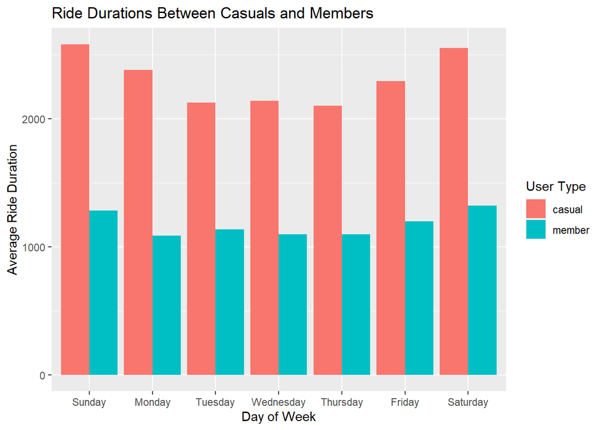

```r
all_trips_v2 %>%
  group_by(member_casual, day_of_week) %>%
  summarise(number_of_rides = n()
            ,average_duration = mean(ride_seconds)) %>%
  arrange(member_casual, day_of_week)  %>%
  ggplot(aes(x = day_of_week, y = average_duration, fill = member_casual)) +
  geom_col(position = "dodge") +
  labs(title = "Ride Durations Between Casuals and Members", x = "Day of Week", y = "Average Ride Duration", fill = "User Type")
```

Creating a bar graph to visualize number of rides throughout the week between casual riders and members.

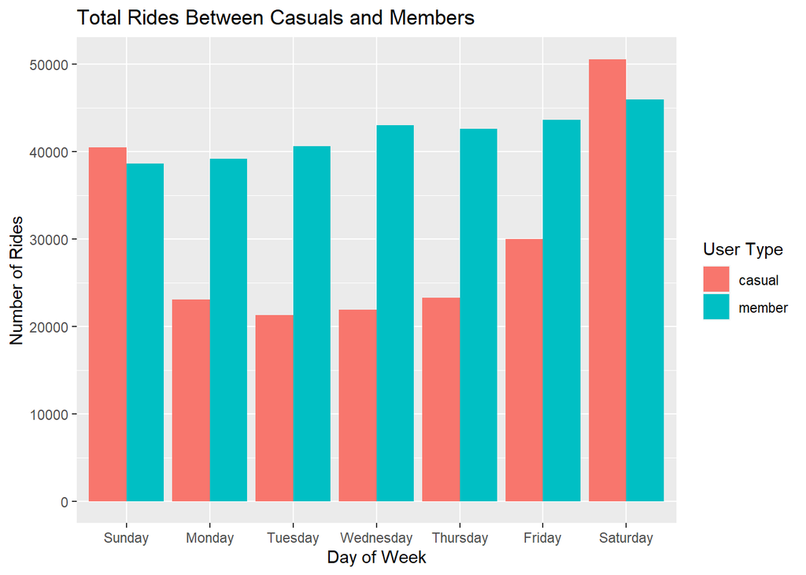

```r
all_trips_v2 %>%
  group_by(member_casual, day_of_week) %>%
  summarise(number_of_rides = n(),
            average_duration = mean(ride_seconds)) %>%
  arrange(member_casual, day_of_week)  %>%
  ggplot(aes(x = day_of_week, y = number_of_rides, fill = member_casual)) +
  geom_col(position = "dodge") +
  labs(title = "Total Rides Between Casuals and Members", x = "Day of Week", y = "Number of Rides", fill = "User Type")
```

This code shows that most activity is in the warmer months. Once it starts getting colder, people are more reluctant on using our bike share service. The two most active and warmest months of the year was July and August 2020. Together, they make up 28.68% of the total number of rides. The worst performing and coldest months in our data set were January and February 2021. They make up just 2.07% and 1.07% of the total number of rides, respectively.

```r
all_trips_v2 %>% group_by(month, year) %>%
                 summarise(number_of_rides = n(),
                           avg_ride_seconds = mean(ride_seconds)) %>%
                 ungroup() %>%
                 mutate(total = sum(number_of_rides), percent_of_total_rides = (number_of_rides / total)* 100)
```

```
## # A tibble: 14 x 6
##    month year  number_of_rides avg_ride_seconds  total percent_of_total_rides
##    <chr> <chr>           <int>            <dbl>  <int>                  <dbl>
##  1 01    2021            10450             827. 504460                   2.07
##  2 02    2021             5406            1105. 504460                   1.07
##  3 03    2021            25371            1245. 504460                   5.03
##  4 04    2020            10727            1578. 504460                   2.13
##  5 04    2021            37083            1301. 504460                   7.35
##  6 05    2020            24717            1931. 504460                   4.90
##  7 05    2021            56244            1417. 504460                  11.1
##  8 06    2020            42814            1915. 504460                   8.49
##  9 07    2020            68908            2118. 504460                  13.7
## 10 08    2020            75789            1980. 504460                  15.0
## 11 09    2020            62540            1699. 504460                  12.4
## 12 10    2020            42315            1587. 504460                   8.39
## 13 11    2020            27948            1453. 504460                   5.54
## 14 12    2020            14148             927. 504460                   2.80
```

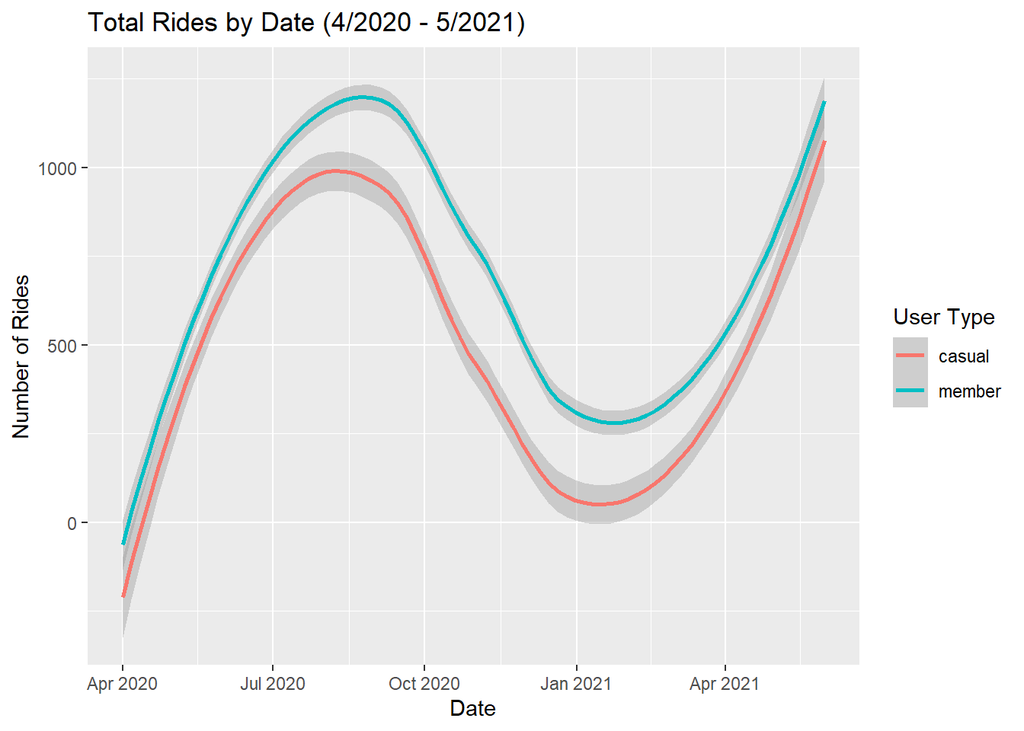

```r
all_trips_v2 %>% group_by(member_casual, date) %>%
                 summarise(number_of_rides = n()) %>%
                 ggplot(aes(x = date, y = number_of_rides, color = member_casual)) + geom_smooth() +
                 labs(title = "Total Rides by Date (4/2020 - 5/2021)", x = "Date", y = "Number of Rides", color = "User Type")
```